# Practical 6: Topic Modeling

Ayoub Bagheri

Introduction to Text Mining with R

# Introduction

In this practical, we will apply a topic modeling approach on news articles to cluster them into different gourps. Here, we are going to use the following packages:

```r
library(tm)
library(tidyverse)
library(tidytext)
library(proxy)
library(topicmodels)
library(caret)
```

# Read data

1. **The dataset that we are going to use is the BBC dataset from practical 3. This dataset consists of 2225 documents and 5 categories: business, entertainment, politics, sport, and tech. For text clustering and topic modeling, we will ignore the labels but we will use them while evaluating models. Load the Rda file of the news dataset.**

```r
load("data/news_dataset.rda")
head(df_final)
```

|  | File_Name | Content | Category | Complete_Filename |
| --- | --- | --- | --- | --- |
| 1 | 001.txt | Ad sales boost Time Warner profit\n\nQuarterly profits at US media giant TimeWarner jumped 76% to $1.13bn (£600m) for the three months to December, from $639m year-earlier.\n\nThe firm, which is now … | business | 001.txt-business |
| 2 | 002.txt | Dollar gains on Greenspan speech\n\nThe dollar has hit its highest level against the euro in almost three months after the Federal Reserve head said the US trade deficit is set to stabilise.\n\nAnd Al… | business | 002.txt-business |
| 3 | 003.txt | Yukos unit buyer faces loan claim\n\nThe owners of embattled Russian oil giant Yukos are to ask the buyer of its former production unit to pay back a $900m (£479m) loan.\n\nState-owned Rosneft bought… | business | 003.txt-business |
| 4 | 004.txt | High fuel prices hit BA's profits\n\nBritish Airways has blamed high fuel prices for a 40% drop in profits.\n\nReporting its results for the three months to 31 December 2004, the airline made a pre-ta… | business | 004.txt-business |
| 5 | 005.txt | Pernod takeover talk lifts Domecq\n\nShares in UK drinks and food firm Allied Domecq have risen on speculation that it could be the target of a takeover by France's Pernod Ricard.\n\nReports in the Wa… | business | 005.txt-business |
| 6 | 006.txt | Japan narrowly escapes recession\n\nJapan's economy teetered on the brink of a technical recession in the three months to September, figures show.\n\nRevised figures indicated growth of just 0.1% - an… | business | 006.txt-business |

```r
# Note that the next chunk (when using `DocumentTermMatrix`) will not work
# returns error invalid multibyte string 1512
# Two possible solutions:
# 1) Omission of the whole observation
# df_final <- df_final[-1512,]
# 2) Omission of the string "\xa315.8m" from that specifc text
df_final[1512,][2] <- gsub("\xa315.8m", "", df_final[1512,][2])
# I prefer the second solution
```

2. **First we must preprocess the corpus. Create a document-term matrix from the `news` column of the dataframe. Complete the following preprocessing steps:**
- convert to lower
- remove stop words
- remove numbers
- remove punctuation
- convert dtm to a dataframe

```r
docs <- VCorpus(VectorSource(df_final$Content))

dtm <- DocumentTermMatrix(docs,
           control = list(tolower = TRUE,
                          removeNumbers = TRUE,
                          removePunctuation = TRUE,
                          stopwords = TRUE
                         ))
# We remove A LOT of features. R is natively very weak with high dimensional data
dtm_cut <- removeSparseTerms(dtm,  sparse = 0.93)
# with sparse = 0.93 the dtm will end up with 359 terms; you can adjust this number based on your available memory
```

# Topic Modeling

Latent Dirichlet allocation (LDA) is a particularly popular method for fitting a topic model. It treats each document as a mixture of topics, and each topic as a mixture of words. This allows documents to “overlap” each other in terms of content, rather than being separated into discrete groups, in a way that mirrors typical use of natural language.

3. **Use the LDA function from the topicmodels package and train an LDA model with 5 topics with the Gibbs sampling method.**

```r
# A LDA topic model with 5 topics; if it takes a lot of time for you to run this change k to 2
out_lda <- LDA(dtm_cut, k = 5, method= "Gibbs", control = list(seed = 321))
out_lda
## A LDA_Gibbs topic model with 5 topics.
```

4. **The tidy() method is originally from the broom package (Robinson 2017), for tidying model objects. The tidytext package provides this method for extracting the per-topic-per-word probabilities, called “beta”, from the LDA model. Use this function and check the beta probabilities for each term and topic.**

```r
lda_topics <- tidy(out_lda, matrix = "beta")
lda_topics
```

| topic | term | beta |
| --- | --- | --- |
| 1 | â£bn | 3.483604e-06 |
| 2 | â£bn | 1.069251e-02 |
| 3 | â£bn | 3.229359e-06 |
| 4 | â£bn | 3.059423e-06 |
| 5 | â£bn | 2.922105e-06 |
| 1 | â£m | 1.400757e-02 |
| 2 | â£m | 6.144623e-03 |
| 3 | â£m | 3.552295e-05 |
| 4 | â£m | 3.059423e-06 |
| 5 | â£m | 6.136421e-05 |

[output cut: 1785 more lines]

5. **Plot the top 20 terms within each topic. Try to label them and compare your labeling with the original categories in the dataset.**

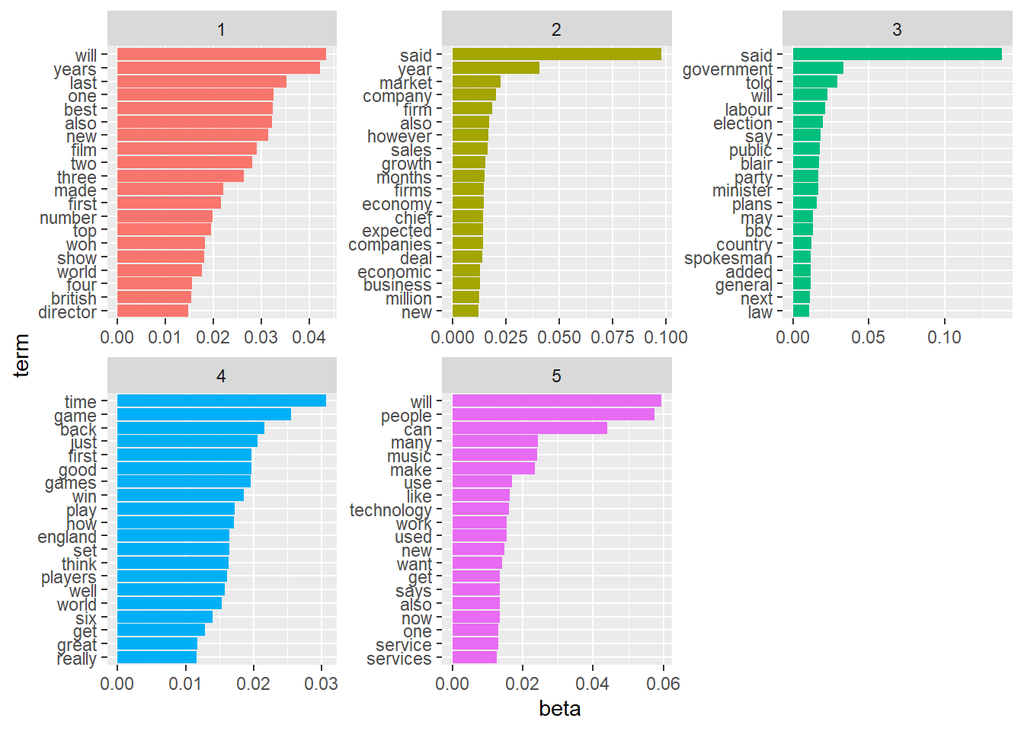

```r
lda_top_terms <- lda_topics %>%
  group_by(topic) %>%
  slice_max(beta, n = 20) %>% # We use dplyr’s slice_max() to find the top 10 terms within each topic.
  ungroup() %>%
  arrange(topic, -beta)

lda_top_terms %>%
  mutate(term = reorder_within(term, beta, topic)) %>%
  ggplot(aes(beta, term, fill = factor(topic))) +
  geom_col(show.legend = FALSE) +
  facet_wrap(~ topic, scales = "free") +
  scale_y_reordered()
```

6. **Use the code below to present and save the terms and topics in a wide format.**

```r
beta_wide <- lda_topics %>%
  mutate(topic = paste0("topic", topic)) %>%
  pivot_wider(names_from = topic, values_from = beta) %>%
  mutate(log_ratio21 = log2(topic2 / topic1)) %>%
  mutate(log_ratio31 = log2(topic3 / topic1))%>%
  mutate(log_ratio41 = log2(topic4 / topic1))%>%
  mutate(log_ratio51 = log2(topic5 / topic1))

beta_wide
```

| term | topic1 | topic2 | topic3 | topic4 | topic5 | log_ratio21 | log_ratio31 | log_ratio41 | log_ratio51 |
| --- | --- | --- | --- | --- | --- | --- | --- | --- | --- |
| â£bn | 3.483604e-06 | 1.069251e-02 | 3.229359e-06 | 3.059423e-06 | 2.922105e-06 | 11.58373167 | -0.1093331 | -0.1873211 | -0.253572572 |
| â£m | 1.400757e-02 | 6.144623e-03 | 3.552295e-05 | 3.059423e-06 | 6.136421e-05 | -1.18881071 | -8.6232401 | -12.1606598 | -7.834593770 |
| able | 3.483604e-06 | 3.319623e-06 | 3.229359e-06 | 9.484212e-05 | 9.003007e-03 | -0.06956127 | -0.1093331 | 4.7668752 | 11.335610395 |
| according | 3.831965e-05 | 1.138963e-02 | 3.229359e-06 | 3.059423e-06 | 2.282164e-03 | 8.21542052 | -3.5687647 | -3.6467528 | 5.896174547 |
| across | 3.483604e-06 | 1.198384e-03 | 3.229359e-06 | 9.484212e-05 | 5.496480e-03 | 8.42629375 | -0.1093331 | 4.7668752 | 10.623711561 |
| action | 3.483604e-06 | 6.971209e-05 | 1.040176e-02 | 3.059423e-06 | 2.922105e-06 | 4.32275615 | 11.5439599 | -0.1873211 | -0.253572572 |
| added | 1.079917e-04 | 5.281521e-03 | 1.149975e-02 | 5.081702e-03 | 1.376312e-03 | 5.61196054 | 6.7345373 | 5.5563189 | 3.671814367 |
| ago | 7.528069e-03 | 3.319623e-06 | 6.781653e-05 | 4.619729e-04 | 3.214316e-05 | -11.14704463 | -6.7944990 | -4.0263998 | -7.871624310 |
| ahead | 1.396925e-03 | 7.004405e-04 | 1.940845e-03 | 4.286252e-03 | 3.214316e-05 | -0.99592051 | 0.4744297 | 1.6174617 | -5.441599380 |
| allow | 3.483604e-06 | 3.319623e-06 | 3.458643e-03 | 3.059423e-06 | 2.925028e-03 | -0.06956127 | 9.9554097 | -0.1873211 | 9.713653687 |

[output cut: 349 more lines]

7. **Use the log ratios to visualize the words with the greatest differences between topic 1 and other topics.**

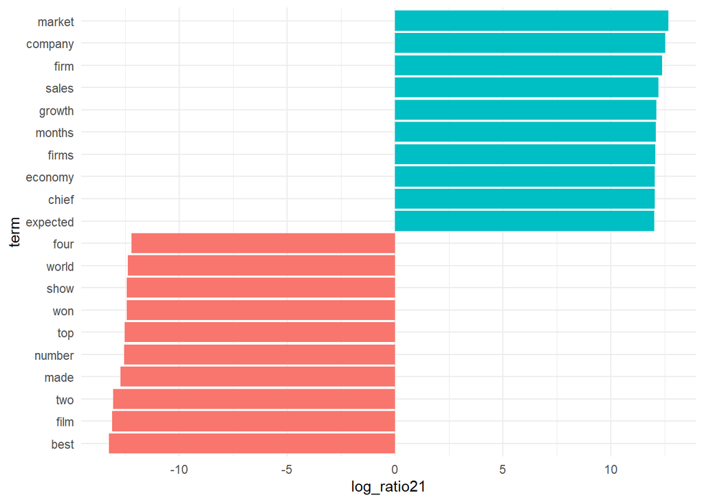

```r
# topic 1 versus topic 2
lda_top_terms1 <- beta_wide %>%
  slice_max(log_ratio21, n = 10) %>%
  arrange(term, -log_ratio21)

lda_top_terms2 <- beta_wide %>%
  slice_max(-log_ratio21, n = 10) %>%
  arrange(term, -log_ratio21)

lda_top_terms12 <- rbind(lda_top_terms1, lda_top_terms2)

# this is for ggplot to understand in which order to plot name on the x axis.
lda_top_terms12$term <- factor(lda_top_terms12$term, levels = lda_top_terms12$term[order(lda_top_terms12$log_ratio21)])

# Words with the greatest difference in beta between topic 2 and topic 1
lda_top_terms12 %>%
  ggplot(aes(log_ratio21, term, fill = (log_ratio21 > 0))) +
  geom_col(show.legend = FALSE) +
  scale_y_reordered() +
  theme_minimal()
```

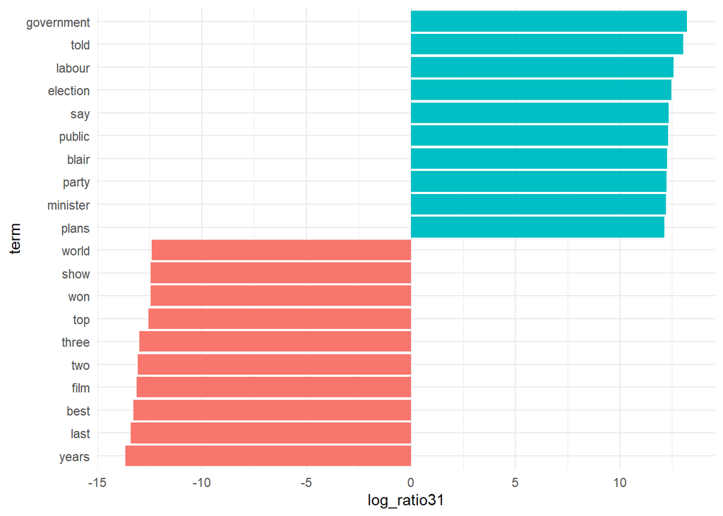

```r
# topic 1 versus topic 3
lda_top_terms1 <- beta_wide %>%
  slice_max(log_ratio31, n = 10) %>%
  arrange(term, -log_ratio31)

lda_top_terms2 <- beta_wide %>%
  slice_max(-log_ratio31, n = 10) %>%
  arrange(term, -log_ratio31)

lda_top_terms13 <- rbind(lda_top_terms1, lda_top_terms2)

# this is for ggplot to understand in which order to plot name on the x axis.
lda_top_terms13$term <- factor(lda_top_terms13$term, levels = lda_top_terms13$term[order(lda_top_terms13$log_ratio31)])

# Words with the greatest difference in beta between topic 2 and topic 1
lda_top_terms13 %>%
  ggplot(aes(log_ratio31, term, fill = (log_ratio31 > 0))) +
  geom_col(show.legend = FALSE) +
  scale_y_reordered() +
  theme_minimal()
```

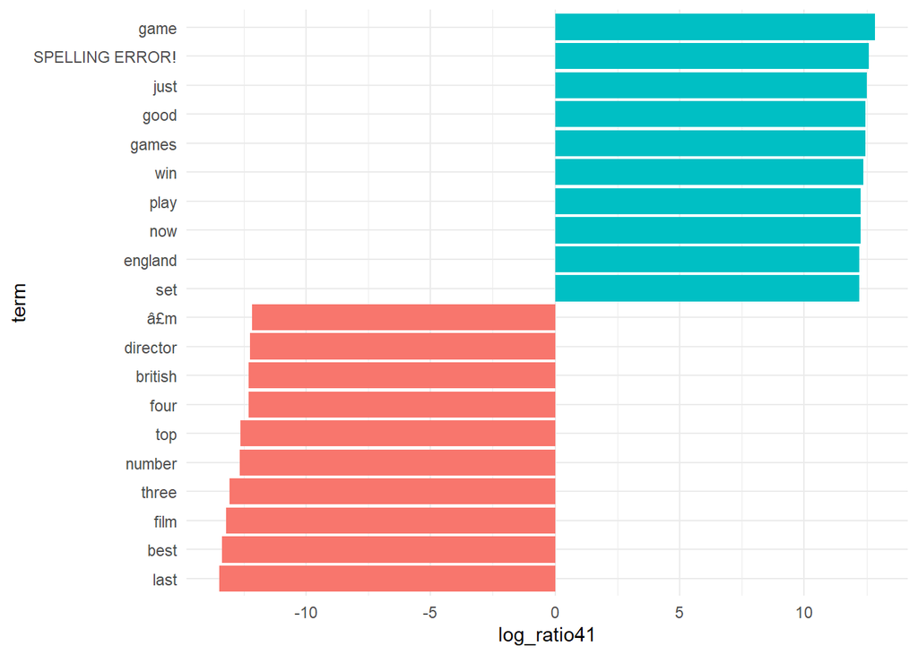

```r
# topic 1 versus topic 4
lda_top_terms1 <- beta_wide %>%
  slice_max(log_ratio41, n = 10) %>%
  arrange(term, -log_ratio41)

lda_top_terms2 <- beta_wide %>%
  slice_max(-log_ratio41, n = 10) %>%
  arrange(term, -log_ratio41)

lda_top_terms14 <- rbind(lda_top_terms1, lda_top_terms2)

lda_top_terms14[1,]$term <- 'SPELLING ERROR!'

# this is for ggplot to understand in which order to plot name on the x axis.
lda_top_terms14$term <- factor(lda_top_terms14$term, levels = lda_top_terms14$term[order(lda_top_terms14$log_ratio41)])

# Words with the greatest difference in beta between topic 2 and topic 1
lda_top_terms14 %>%
  ggplot(aes(log_ratio41, term, fill = (log_ratio41 > 0))) +
  geom_col(show.legend = FALSE) +
  scale_y_reordered() +
  theme_minimal()
```

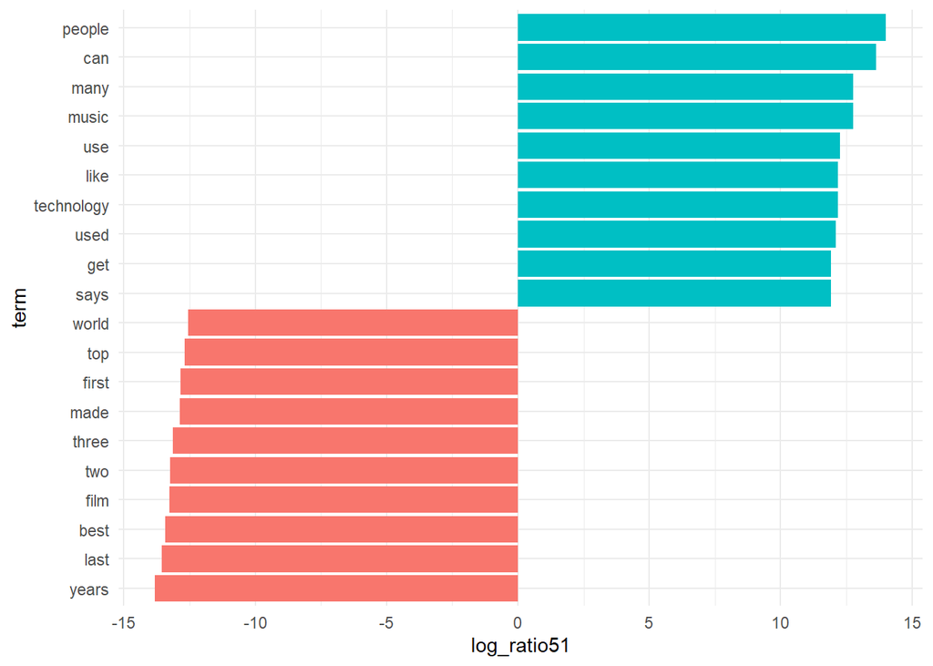

```r
# topic 1 versus topic 5
lda_top_terms1 <- beta_wide %>%
  slice_max(log_ratio51, n = 10) %>%
  arrange(term, -log_ratio51)

lda_top_terms2 <- beta_wide %>%
  slice_max(-log_ratio51, n = 10) %>%
  arrange(term, -log_ratio51)

lda_top_terms15 <- rbind(lda_top_terms1, lda_top_terms2)

# this is for ggplot to understand in which order to plot name on the x axis.
lda_top_terms15$term <- factor(lda_top_terms15$term, levels = lda_top_terms15$term[order(lda_top_terms15$log_ratio51)])

# Words with the greatest difference in beta between topic 2 and topic 1
lda_top_terms15 %>%
  ggplot(aes(log_ratio51, term, fill = (log_ratio51 > 0))) +
  geom_col(show.legend = FALSE) +
  scale_y_reordered() +
  theme_minimal()
```

8. **Besides estimating each topic as a mixture of words, LDA also models each document as a mixture of topics. We can examine the per-document-per-topic probabilities, called “gamma”, with the matrix = “gamma” argument to tidy(). Call this function for your LDA model and save the probabilities in a varibale named lda_documents.**

```r
lda_documents <- tidy(out_lda, matrix = "gamma")
```

9. **Check the topic probabilities for some of the documents (for example documents 1, 1000, 2000, 2225). Also look at the contents of some them.**

```r
lda_documents[lda_documents$document == 1,]
```

| document | topic | gamma |
| --- | --- | --- |
| 1 | 1 | 0.1666667 |
| 1 | 2 | 0.3015873 |
| 1 | 3 | 0.1587302 |
| 1 | 4 | 0.1825397 |
| 1 | 5 | 0.1904762 |

```r
lda_documents[lda_documents$document == 1000,]
```

| document | topic | gamma |
| --- | --- | --- |
| 1000 | 1 | 0.1666667 |
| 1000 | 2 | 0.1315789 |
| 1000 | 3 | 0.3245614 |
| 1000 | 4 | 0.2192982 |
| 1000 | 5 | 0.1578947 |

```r
lda_documents[lda_documents$document == 2000,]
```

| document | topic | gamma |
| --- | --- | --- |
| 2000 | 1 | 0.2000000 |
| 2000 | 2 | 0.1789474 |
| 2000 | 3 | 0.2526316 |
| 2000 | 4 | 0.1368421 |
| 2000 | 5 | 0.2315789 |

```r
lda_documents[lda_documents$document == 2225,]
```

| document | topic | gamma |
| --- | --- | --- |
| 2225 | 1 | 0.0968750 |
| 2225 | 2 | 0.0500000 |
| 2225 | 3 | 0.0390625 |
| 2225 | 4 | 0.4984375 |
| 2225 | 5 | 0.3156250 |

```r
tidy(dtm_cut) %>%
  filter(document == 2225) %>%
  arrange(desc(count))
```

| document | term | count |
| --- | --- | --- |
| 2225 | game | 22 |
| 2225 | games | 22 |
| 2225 | online | 22 |
| 2225 | time | 20 |
| 2225 | playing | 19 |
| 2225 | can | 15 |
| 2225 | people | 15 |
| 2225 | play | 15 |
| 2225 | life | 13 |
| 2225 | world | 13 |

[output cut: 156 more lines]

```r
df_final[2225,]$Content
```

```
## [1] "Losing yourself in online gaming\n\nOnline role playing games are time-consuming, but enthralling flights from reality. But are some people taking their fantasy lives too seriously?\n\nWhen video game World of Warcraft hit the shops in Europe last week fans wrote in to the BBC website to exp…
```

10. **Visualize the topic probabilities for example documents using boxplots.**

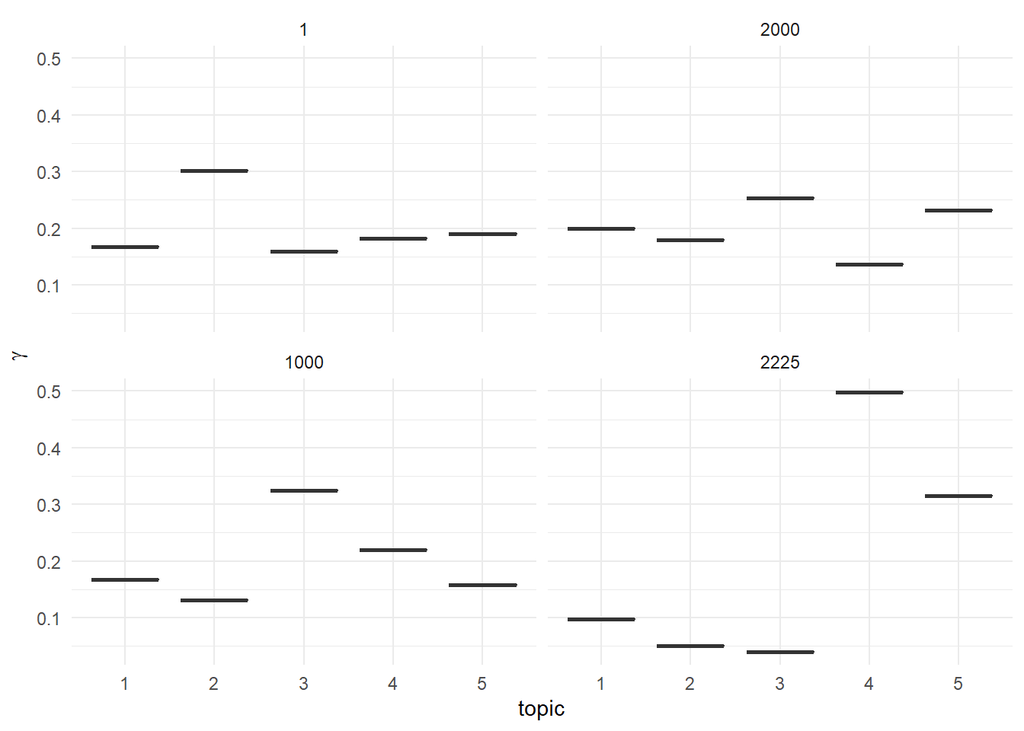

```r
# reorder titles in order of topic 1, topic 2, etc before plotting
lda_documents[lda_documents$document %in% c(1, 1000, 2000, 2225),] %>%
  mutate(document = reorder(document, gamma * topic)) %>%
  ggplot(aes(factor(topic), gamma)) +
  geom_boxplot() +
  facet_wrap(~ document) +
  labs(x = "topic", y = expression(gamma)) +
  theme_minimal()
```

11. **Check the predicted topics against the provided labels (column: Category) in the original data frame.**

```r
results <-
lda_documents %>%
  mutate(document = as.numeric(document)) %>%
  group_by(document) %>%
  filter(gamma == max(gamma)) %>%
  arrange(document) %>%
  ungroup() %>%
  left_join(rowid_to_column(select(df_final, Category), "document")) %>%
  mutate(topic = if_else(topic == 1, "entertainment",
                         if_else(topic == 2, "business",
                                 if_else(topic == 3, "politics",
                                         if_else(topic == 4, "sport", "tech")))))

confusionMatrix(factor(results$topic), factor(results$Category))
## Confusion Matrix and Statistics
##
##                Reference
## Prediction      business entertainment politics sport tech
##   business           440            17       22     7   26
##   entertainment       15           307       11    66   18
##   politics            53            24      351    34   15
##   sport                4            25        6   410   31
##   tech                12            30       33    13  314
##
## Overall Statistics
##
##                Accuracy : 0.7977
##                  95% CI : (0.7807, 0.814)
##     No Information Rate : 0.232
##     P-Value [Acc > NIR] : < 2.2e-16
##
##                   Kappa : 0.7466
##
##  Mcnemar's Test P-Value : 8.137e-13
##
## Statistics by Class:
##
##                      Class: business Class: entertainment Class: politics
## Sensitivity                   0.8397               0.7618          0.8298
## Specificity                   0.9591               0.9415          0.9323
## Pos Pred Value                0.8594               0.7362          0.7358
## Neg Pred Value                0.9526               0.9486          0.9602
## Prevalence                    0.2294               0.1764          0.1852
## Detection Rate                0.1926               0.1344          0.1537
## Detection Prevalence          0.2242               0.1826          0.2088
## Balanced Accuracy             0.8994               0.8517          0.8810
##                      Class: sport Class: tech
## Sensitivity                0.7736      0.7772
## Specificity                0.9624      0.9532
## Pos Pred Value             0.8613      0.7811
## Neg Pred Value             0.9336      0.9522
## Prevalence                 0.2320      0.1769
## Detection Rate             0.1795      0.1375
## Detection Prevalence       0.2084      0.1760
## Balanced Accuracy          0.8680      0.8652
```

# Alternative LDA implementations

The LDA() function in the topicmodels package is only one implementation of the latent Dirichlet allocation algorithm. For example, the mallet package (Mimno 2013) implements a wrapper around the MALLET Java package for text classification tools, and the tidytext package provides tidiers for this model output as well. The textmineR package has extensive functionality for topic modeling. You can fit Latent Dirichlet Allocation (LDA), Correlated Topic Models (CTM), and Latent Semantic Analysis (LSA) from within textmineR (https://cran.r-project.org/web/packages/textmineR/vignettes/c_topic_modeling.html).

# Summary

In this practical, we learned about:

- Topic modeling
- LDA

End of Practical